# Informe mensual de las cotizaciones al Sistema de la Protección Social

Junio de 2025

# 1 Introducción

Para el periodo analizado, se registró un total de **13.143.806** cotizantes en el sistema. El documento se estructura en varias secciones: primero, se presentan los resultados generales, detallando el comportamiento de las novedades y la distribución de los cotizantes según su **Ingreso Base de Cotización (IBC)**. Posteriormente, se exploran las **dinámicas demográficas** por sexo y rangos de edad y la **distribución geográfica** de los cotizantes a nivel departamental, analizando las variaciones más significativas.

# 2 Resultados generales

Para **mayo de 2025**, el número total de cotizantes al sistema muestra un crecimiento anual del **-3,4%**. Este resultado representa **una desaceleración** en comparación con la variación anual observada en el mismo mes del año anterior, que fue del **-0,2%**. La variación mensual, por su parte, se ubicó en **-0,3%**.

El comportamiento general se explica principalmente por la dinámica de los **10.917,9 mil cotizantes dependientes**, que registraron una variación anual del **-2,8%**. Por otro lado, los **2.225,9 mil cotizantes independientes** mostraron una variación anual del **-6,0%**. La siguiente tabla presenta un resumen histórico de estos indicadores.

Total cotizantes (miles) en MAYO de cada año, junto con sus variaciones anuales y mensuales (%)

| Año | Total | Var mes | Var año | Dependientes | Var mes | Var año | Dep. privados | Var mes | Var año | Indepen. | Var mes | Var año |
| --- | --- | --- | --- | --- | --- | --- | --- | --- | --- | --- | --- | --- |
| 2025 | 13.144 | -0,3% | -3,4% | 10.918 | 0,4% | -2,8% | 9.142 | 1,6% | -1,9% | 2.226 | -3,5% | -6,0% |
| 2024 | 13.602 | 0,4% | -0,2% | 11.233 | 0,2% | -0,4% | 9.322 | -0,2% | -1,0% | 2.369 | 1,2% | 0,9% |
| 2023 | 13.627 | 0,9% | 2,2% | 11.278 | 0,9% | 2,7% | 9.414 | 0,4% | 2,7% | 2.348 | 0,9% | 0,2% |
| 2022 | 13.329 | 1,5% | 9,6% | 10.985 | 1,7% | 10,4% | 9.169 | 1,0% | 10,3% | 2.344 | 0,4% | 5,9% |
| 2021 | 12.161 | 0,0% | 8,2% | 9.949 | -0,1% | 8,6% | 8.316 | -0,7% | 8,5% | 2.212 | 0,4% | 6,4% |
| 2020 | 11.237 | 0,1% | -7,8% | 9.158 | 0,1% | -8,6% | 7.661 | -0,1% | -7,4% | 2.079 | 0,5% | -4,2% |
| 2019 | 12.187 | 1,1% | 2,6% | 10.016 | 1,1% | 2,6% | 8.271 | 0,8% | 2,5% | 2.171 | 1,3% | 2,6% |
| 2018 | 11.880 | 0,5% | NA% | 9.766 | 0,5% | NA% | 8.067 | 0,4% | NA% | 2.115 | 0,0% | NA% |

## 2.1 Comportamiento de las novedades

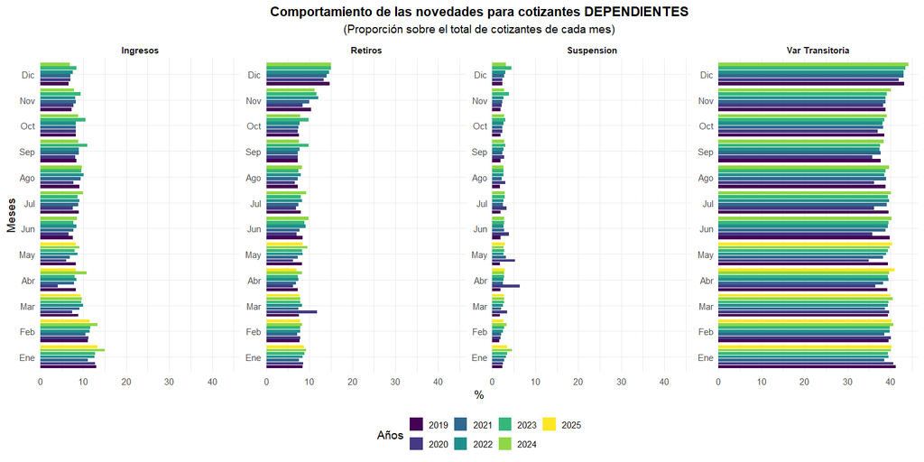

En **mayo de 2025** se registraron **1.062.741** ingresos, **1.041.763** retiros y **316.321** suspensiones temporales. Estas cifras corresponden al **8,1%**, **7,9%** y **2,4%** de las relaciones laborales activas en este periodo, respectivamente. Esto implica que se registraron **1.02** ingresos por cada retiro, indicando una dinámica de rotación laboral.

La participación de ingresos y retiros en el mismo mes de **2024** fue del **8,8%** y **8,9%**. En comparación, durante el mismo mes de **2021** (año de la pandemia), la participación de ingresos, retiros y suspensiones fue del **6,6%**, **6,8%** y **2,6%**, evidenciando una mayor variabilidad en la estabilidad laboral formal durante ese periodo.

Variación mensual (%) del número de cotizantes DEPENDIENTES con novedades en los últimos 5 años

| Mes | Ingresos 2021 | Ingresos 2022 | Ingresos 2023 | Ingresos 2024 | Ingresos 2025 | Retiros 2021 | Retiros 2022 | Retiros 2023 | Retiros 2024 | Retiros 2025 | Suspensión 2021 | Suspensión 2022 | Suspensión 2023 | Suspensión 2024 | Suspensión 2025 | V. Transitoria 2021 | V. Transitoria 2022 | V. Transitoria 2023 | V. Transitoria 2024 | V. Transitoria 2025 |
| --- | --- | --- | --- | --- | --- | --- | --- | --- | --- | --- | --- | --- | --- | --- | --- | --- | --- | --- | --- | --- |
| Ene | 53.9 | 76.6 | 66.5 | 72.6 | 90.4 | -44.4 | -40.2 | -40.6 | -40.0 | -43.0 | 13.6 | 12.9 | 9.4 | 2.2 | 7.2 | -10.4 | -9.7 | -10.5 | -9.7 | -10.0 |
| Feb | -1.6 | -5.4 | -6.0 | -8.3 | -9.9 | -1.8 | -3.9 | -8.9 | -7.1 | -6.7 | -23.7 | -19.4 | -18.2 | -26.2 | -20.3 | 3.8 | 4.2 | 4.4 | 4.2 | 3.5 |
| Mar | -11.8 | -11.2 | -16.1 | -26.7 | -17.9 | 6.1 | 8.0 | 2.3 | -4.8 | 0.7 | 3.7 | 3.2 | 3.2 | -15.4 | 4.0 | 2.4 | 1.5 | 1.4 | 0.3 | 0.7 |
| Abr | -13.0 | -15.5 | -15.7 | 13.0 | -13.5 | -6.7 | -10.1 | -6.9 | 7.7 | -12.1 | 22.0 | 8.8 | 4.4 | -1.2 | 4.4 | -0.1 | 0.6 | 0.0 | -0.2 | 0.2 |
| May | -12.9 | 6.5 | 1.1 | -15.3 | 0.0 | 5.3 | 15.1 | 15.7 | 14.4 | 21.4 | 27.6 | 2.0 | -0.5 | -2.3 | 0.1 | -0.2 | 0.2 | 0.8 | 0.5 | -1.0 |
| Jun | 14.2 | -3.7 | -3.6 | -6.7 | NA | 6.8 | 8.4 | 5.9 | 2.4 | NA | -12.2 | -4.1 | 1.2 | 4.3 | NA | 1.9 | 1.1 | 0.3 | 0.0 | NA |
| Jul | 15.4 | 7.4 | 12.5 | 16.9 | NA | -2.1 | -10.0 | -9.9 | -5.0 | NA | -11.2 | 4.1 | 1.0 | 4.5 | NA | 1.8 | 0.5 | -0.4 | 0.0 | NA |
| Ago | 8.5 | 12.9 | 9.8 | -1.4 | NA | 0.0 | 0.2 | -4.7 | -11.0 | NA | -6.1 | 0.5 | -4.7 | -10.2 | NA | 1.7 | -0.5 | -0.2 | -0.2 | NA |
| Sep | -3.1 | -8.8 | 16.4 | -9.1 | NA | 0.9 | -2.6 | 32.1 | -6.2 | NA | 4.9 | 1.5 | 12.9 | 10.0 | NA | -1.3 | -1.8 | -2.1 | -2.1 | NA |
| Oct | -6.0 | -7.7 | -3.6 | 1.0 | NA | 2.9 | -0.1 | 1.0 | 3.1 | NA | 2.0 | 2.7 | 2.4 | -2.4 | NA | 2.4 | 2.5 | 2.8 | 2.7 | NA |
| Nov | 0.6 | -2.1 | -10.7 | -10.7 | NA | 34.5 | 56.2 | 18.1 | 42.2 | NA | 1.0 | -3.2 | 25.7 | -0.3 | NA | 2.6 | 1.9 | 1.5 | 1.9 | NA |
| Dic | -19.0 | -12.5 | -15.3 | -18.0 | NA | 35.8 | 14.3 | 21.8 | 26.7 | NA | 11.6 | 10.3 | 8.2 | 9.8 | NA | 6.6 | 4.7 | 4.5 | 3.7 | NA |

Variación anual (%) del número de cotizantes DEPENDIENTES con novedades en los últimos 5 años

| Mes | Ingresos 2021 | Ingresos 2022 | Ingresos 2023 | Ingresos 2024 | Ingresos 2025 | Retiros 2021 | Retiros 2022 | Retiros 2023 | Retiros 2024 | Retiros 2025 | Suspensión 2021 | Suspensión 2022 | Suspensión 2023 | Suspensión 2024 | Suspensión 2025 | V. Transitoria 2021 | V. Transitoria 2022 | V. Transitoria 2023 | V. Transitoria 2024 | V. Transitoria 2025 |
| --- | --- | --- | --- | --- | --- | --- | --- | --- | --- | --- | --- | --- | --- | --- | --- | --- | --- | --- | --- | --- |
| Ene | -15.9 | 23.4 | 6.0 | 17.4 | -11.3 | -14.2 | 21.4 | 8.3 | 5.0 | -6.4 | 9.6 | 22.8 | 12.8 | 37.4 | -25.6 | -8.2 | 11.6 | 3.5 | 2.5 | 0.1 |
| Feb | -9.1 | 18.6 | 5.5 | 14.4 | -12.8 | -11.1 | 18.8 | 2.6 | 7.2 | -6.0 | 2.6 | 29.9 | 14.5 | 24.0 | -19.6 | -6.5 | 12.0 | 3.7 | 2.3 | -0.6 |
| Mar | 20.0 | 19.6 | -0.4 | 0.0 | -2.4 | -36.6 | 20.9 | -2.8 | -0.3 | -0.6 | -40.9 | 29.2 | 14.5 | 1.6 | -1.3 | -3.1 | 11.1 | 3.7 | 1.1 | -0.2 |
| Abr | 109.2 | 16.1 | -0.6 | 34.0 | -25.3 | 21.3 | 16.6 | 0.6 | 15.4 | -18.9 | -57.2 | 15.2 | 10.0 | -3.9 | 4.3 | 14.6 | 11.8 | 3.1 | 1.0 | 0.2 |
| May | 21.5 | 41.9 | -5.7 | 12.3 | -11.8 | 28.4 | 27.4 | 1.1 | 14.1 | -13.9 | -34.7 | -7.9 | 7.3 | -5.5 | 6.8 | 19.2 | 12.3 | 3.7 | 0.7 | -1.3 |
| Jun | 27.5 | 19.7 | -5.7 | 8.8 | NA | 20.7 | 29.3 | -1.2 | 10.3 | NA | -20.7 | 0.6 | 13.2 | -2.6 | NA | 17.8 | 11.4 | 2.9 | 0.4 | NA |
| Jul | 25.8 | 11.4 | -1.2 | 13.0 | NA | 18.3 | 18.8 | -1.1 | 16.2 | NA | -20.7 | 17.9 | 9.8 | 0.8 | NA | 17.3 | 10.0 | 1.9 | 0.8 | NA |
| Ago | 32.6 | 15.9 | -3.9 | 1.4 | NA | 22.8 | 19.0 | -5.9 | 8.6 | NA | -19.8 | 26.1 | 4.2 | -5.1 | NA | 17.8 | 7.6 | 2.1 | 0.9 | NA |
| Sep | 20.7 | 9.0 | 22.7 | -20.8 | NA | 8.4 | 14.9 | 27.7 | -22.9 | NA | -5.8 | 22.1 | 15.9 | -7.5 | NA | 15.4 | 7.0 | 1.9 | 0.9 | NA |
| Oct | 9.9 | 7.1 | 28.1 | -17.0 | NA | 11.3 | 11.5 | 29.1 | -21.2 | NA | 9.1 | 22.9 | 15.4 | -11.8 | NA | 12.9 | 7.1 | 2.2 | 0.8 | NA |
| Nov | 19.0 | 4.2 | 16.9 | -17.0 | NA | 28.7 | 29.5 | -2.4 | -5.2 | NA | 18.7 | 17.8 | 49.9 | -30.1 | NA | 11.5 | 6.4 | 1.8 | 1.3 | NA |
| Dic | 7.6 | 12.5 | 13.2 | -19.6 | NA | 12.9 | 9.0 | 4.0 | -1.3 | NA | 23.5 | 16.5 | 47.0 | -29.1 | NA | 10.7 | 4.4 | 1.6 | 0.5 | NA |

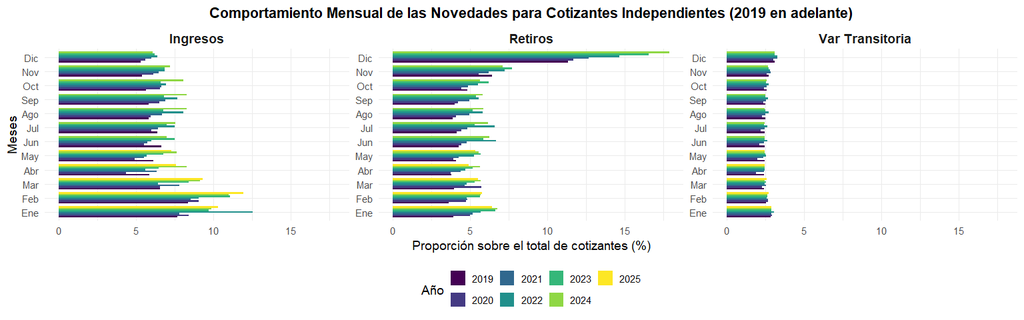

En el caso de los cotizantes independientes, se registraron **162.885** ingresos y **119.031** retiros durante **mayo de 2025**. Estas cifras representan el **7,3%** y el **5,3%** del total de cotizantes de esta tipología, respectivamente. La relación fue de **1.37** ingresos por cada retiro. En comparación, para el mismo mes del año anterior, las participaciones fueron del **7,6%** para ingresos y **5,6%** para retiros.

Variación mensual (%) del número de cotizantes INDEPENDIENTES con novedades en los últimos 5 años

| Mes | Ingresos 2021 | Ingresos 2022 | Ingresos 2023 | Ingresos 2024 | Ingresos 2025 | Retiros 2021 | Retiros 2022 | Retiros 2023 | Retiros 2024 | Retiros 2025 | V. Transitoria 2021 | V. Transitoria 2022 | V. Transitoria 2023 | V. Transitoria 2024 | V. Transitoria 2025 |
| --- | --- | --- | --- | --- | --- | --- | --- | --- | --- | --- | --- | --- | --- | --- | --- |
| Ene | 29.7 | 103.2 | 39.6 | 44.5 | 56.2 | -58.7 | -56.4 | -58.2 | -62.7 | -66.8 | -9.7 | -9.3 | -17.6 | -15.0 | -13.6 |
| Feb | 13.1 | -25.4 | 19.8 | 16.0 | 22.3 | -3.5 | -12.8 | -10.7 | -12.7 | -5.2 | -4.7 | -12.7 | -5.8 | -5.6 | -1.2 |
| Mar | -6.2 | -28.0 | -22.2 | -14.3 | -20.0 | -1.0 | 1.2 | -4.3 | 3.4 | -2.2 | -2.4 | -3.2 | 0.2 | -3.3 | -2.4 |
| Abr | -17.9 | -12.7 | -22.8 | -7.7 | -21.6 | -4.6 | -1.5 | -1.4 | 1.6 | -14.1 | -3.4 | 0.2 | -4.1 | 2.2 | -8.2 |
| May | -12.2 | 1.9 | 5.6 | -6.8 | -7.0 | -2.0 | 12.1 | 11.0 | -0.4 | 4.7 | -1.2 | 2.7 | 2.7 | 0.8 | -3.3 |
| Jun | 4.7 | 4.7 | 11.6 | -7.9 | NA | 12.7 | 26.7 | 3.6 | 12.5 | NA | 2.6 | 3.1 | 0.2 | -0.3 | NA |
| Jul | 12.7 | 25.4 | -6.5 | 8.8 | NA | 1.2 | -1.2 | -9.4 | -0.6 | NA | 2.2 | 1.0 | -1.2 | 1.4 | NA |
| Ago | 5.3 | 8.8 | -2.4 | 11.2 | NA | 4.3 | -10.8 | -1.7 | -3.4 | NA | 2.6 | 4.0 | 2.8 | 1.6 | NA |
| Sep | 4.1 | -4.0 | 2.0 | 1.6 | NA | 0.8 | -3.1 | 5.4 | 0.5 | NA | 2.5 | -0.2 | 2.1 | 2.3 | NA |
| Oct | -3.2 | -8.7 | -2.9 | -1.5 | NA | -0.6 | -0.3 | 15.2 | -1.7 | NA | 3.2 | 1.4 | 2.7 | 4.8 | NA |
| Nov | -1.5 | -1.1 | 3.7 | -10.1 | NA | 28.3 | 31.4 | 24.3 | 26.8 | NA | 9.6 | 4.1 | 6.4 | 4.5 | NA |
| Dic | -8.9 | -9.2 | -12.5 | -19.4 | NA | 99.9 | 96.5 | 107.9 | 139.5 | NA | 13.8 | 12.8 | 10.1 | 10.1 | NA |

Variación anual (%) del número de cotizantes INDEPENDIENTES con novedades en los últimos 5 años

| Mes | Ingresos 2021 | Ingresos 2022 | Ingresos 2023 | Ingresos 2024 | Ingresos 2025 | Retiros 2021 | Retiros 2022 | Retiros 2023 | Retiros 2024 | Retiros 2025 | Suspensión 2021 | Suspensión 2022 | Suspensión 2023 | Suspensión 2024 | Suspensión 2025 | V. Transitoria 2021 | V. Transitoria 2022 | V. Transitoria 2023 | V. Transitoria 2024 | V. Transitoria 2025 |
| --- | --- | --- | --- | --- | --- | --- | --- | --- | --- | --- | --- | --- | --- | --- | --- | --- | --- | --- | --- | --- |
| Ene | -7.0 | 74.3 | -25.0 | 0.6 | 8.1 | 3.7 | 19.1 | 13.4 | 1.1 | -1.7 | 150.0 | -35.0 | -34.6 | 2117.6 | -70.0 | -0.7 | 14.3 | -7.8 | -1.3 | 3.0 |
| Feb | -5.6 | 15.0 | 20.3 | -2.5 | 13.9 | 1.9 | 7.6 | 16.2 | -1.2 | 6.8 | 4.0 | 23.1 | 21.9 | 712.8 | -49.8 | 0.4 | 4.7 | -0.5 | -1.1 | 7.7 |
| Mar | 21.9 | -11.7 | 30.0 | 7.5 | 6.3 | -17.2 | 10.1 | 9.9 | 6.6 | 1.0 | -72.2 | 133.3 | 8.6 | 815.8 | -67.8 | 14.7 | 3.9 | 3.0 | -4.5 | 8.7 |
| Abr | 54.6 | -6.2 | 15.0 | 28.5 | -9.7 | 23.7 | 13.7 | 10.0 | 9.9 | -14.5 | -34.9 | -3.6 | 48.1 | 725.0 | -67.6 | 35.5 | 7.8 | -1.4 | 1.8 | -2.3 |
| May | 19.8 | 9.0 | 19.1 | 13.4 | -9.9 | 16.3 | 30.0 | 9.0 | -1.4 | -10.2 | -50.0 | -9.1 | 70.0 | 564.7 | -52.7 | 28.8 | 12.0 | -1.4 | -0.1 | -6.3 |
| Jun | 11.2 | 9.0 | 27.1 | -6.4 | NA | 15.0 | 46.1 | -10.9 | 7.0 | NA | 92.0 | -37.5 | 53.3 | 367.4 | NA | 23.5 | 12.5 | -4.2 | -0.6 | NA |
| Jul | 13.9 | 21.3 | -5.2 | 8.9 | NA | 15.4 | 42.6 | -18.2 | 17.3 | NA | -53.6 | -26.9 | 173.7 | 238.5 | NA | 18.9 | 11.2 | -6.3 | 2.0 | NA |
| Ago | 20.2 | 25.3 | -14.9 | 24.0 | NA | 28.4 | 22.0 | -10.0 | 15.3 | NA | -59.6 | 68.4 | 18.8 | 465.8 | NA | 17.2 | 12.7 | -7.4 | 0.7 | NA |
| Sep | 11.9 | 15.6 | -9.7 | 23.5 | NA | 24.3 | 17.3 | -2.1 | 10.0 | NA | -52.9 | 0.0 | 112.5 | 207.8 | NA | 13.6 | 9.8 | -5.2 | 1.0 | NA |
| Oct | 6.1 | 9.0 | -3.9 | 25.3 | NA | 15.6 | 17.6 | 13.2 | -6.2 | NA | -3.4 | 10.7 | 325.8 | -34.8 | NA | 12.0 | 7.9 | -4.0 | 3.0 | NA |
| Nov | 10.8 | 9.5 | 0.8 | 8.7 | NA | 17.3 | 20.4 | 7.1 | -4.3 | NA | -52.3 | -33.3 | 2842.9 | -84.2 | NA | 13.5 | 2.4 | -1.9 | 1.2 | NA |
| Dic | 11.2 | 9.1 | -2.8 | 0.1 | NA | 12.7 | 18.4 | 13.3 | 10.3 | NA | -70.0 | 0.0 | 1875.0 | -82.3 | NA | 13.9 | 1.5 | -4.3 | 1.2 | NA |

## 2.2 Resumen por Ingreso Base de Cotización (IBC)

La distribución de los cotizantes según su Ingreso Base de Cotización (IBC) muestra una alta concentración en los rangos más bajos. Para **mayo de 2025**, el **46,4%** de los cotizantes reportó un IBC de hasta 1 Salario Mínimo Mensual Legal Vigente (SMMLV), una cifra similar al **47,0%** observado en el mismo mes del año anterior.

Total cotizantes por rangos de IBC para MAYO 2025, su distribución y variaciones

| Tipo | IBC | Datos 2025 Total | Datos 2025 Distribución | Datos 2025 Var. Mes | Datos 2025 Var. Año | Datos 2024 Total | Datos 2024 Distribución | Datos 2024 Var. Mes | Datos 2024 Var. Año |
| --- | --- | --- | --- | --- | --- | --- | --- | --- | --- |
| **Dependientes** |  |  |  |  |  |  |  |  |  |
| Dependientes | 1._<1SMMLV | 1.436,3 | 13,2% | 3,9% | -2,6% | 1.475,0 | 13,1% | 0,7% | 4,8% |
| Dependientes | 2._1SMMLV | 3.044,4 | 27,9% | 3,0% | -4,4% | 3.183,6 | 28,3% | -0,6% | -3,7% |
| Dependientes | 3.1_2SMMLV | 3.828,8 | 35,1% | 0,3% | 0,6% | 3.804,4 | 33,9% | 1,0% | 0,9% |
| Dependientes | 4.2_3SMMLV | 1.074,1 | 9,8% | -4,2% | -1,5% | 1.090,6 | 9,7% | -1,1% | -1,2% |
| Dependientes | 5.3_5SMMLV | 870,5 | 8,0% | -5,1% | -6,8% | 934,3 | 8,3% | 0,1% | -0,0% |
| Dependientes | 6.>5SMMLV | 663,9 | 6,1% | -2,6% | -10,9% | 745,0 | 6,6% | 1,8% | -1,1% |
| Dependientes | 7.Total | 10.917,9 | 100,0% | 0,4% | -2,8% | 11.232,8 | 100,0% | 0,2% | -0,4% |
| **Independientes** |  |  |  |  |  |  |  |  |  |
| Independientes | 1._<1SMMLV | 122,3 | 5,5% | 5,5% | -8,3% | 133,3 | 5,6% | 0,4% | 5,6% |
| Independientes | 2._1SMMLV | 1.495,9 | 67,2% | -4,3% | -6,7% | 1.603,2 | 67,7% | 0,5% | 2,1% |
| Independientes | 3.1_2SMMLV | 409,6 | 18,4% | -3,5% | -2,1% | 418,6 | 17,7% | 3,2% | -3,5% |
| Independientes | 4.2_3SMMLV | 99,7 | 4,5% | -3,2% | -1,7% | 101,5 | 4,3% | 4,1% | -3,9% |
| Independientes | 5.3_5SMMLV | 54,2 | 2,4% | -3,2% | -17,1% | 65,4 | 2,8% | 2,8% | 4,1% |
| Independientes | 6.>5SMMLV | 44,2 | 2,0% | -3,4% | -6,0% | 47,0 | 2,0% | 0,5% | -4,9% |
| Independientes | 7.Total | 2.225,9 | 100,0% | -3,5% | -6,0% | 2.369,0 | 100,0% | 1,2% | 0,9% |
| **Total** |  |  |  |  |  |  |  |  |  |
| Total | 1._<1SMMLV | 1.558,6 | 11,9% | 4,0% | -3,1% | 1.608,4 | 11,8% | 0,6% | 4,9% |
| Total | 2._1SMMLV | 4.540,3 | 34,5% | 0,5% | -5,2% | 4.786,8 | 35,2% | -0,3% | -1,9% |
| Total | 3.1_2SMMLV | 4.238,4 | 32,2% | -0,1% | 0,4% | 4.223,0 | 31,0% | 1,2% | 0,4% |
| Total | 4.2_3SMMLV | 1.173,8 | 8,9% | -4,2% | -1,5% | 1.192,0 | 8,8% | -0,6% | -1,4% |
| Total | 5.3_5SMMLV | 924,7 | 7,0% | -5,0% | -7,5% | 999,7 | 7,3% | 0,2% | 0,3% |
| Total | 6.>5SMMLV | 708,0 | 5,4% | -2,6% | -10,6% | 791,9 | 5,8% | 1,7% | -1,4% |
| Total | 7.Total | 13.143,8 | 100,0% | -0,3% | -3,4% | 13.601,8 | 100,0% | 0,4% | -0,2% |

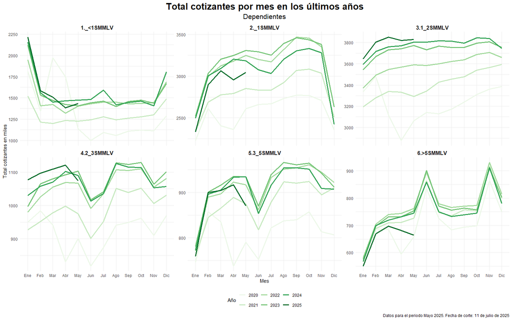

Total cotizantes DEPENDIENTES histórico por rango IBC.

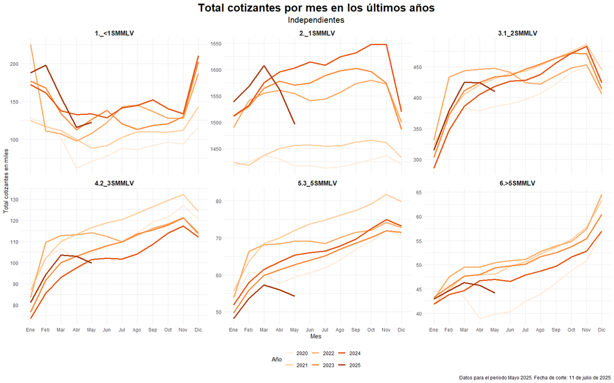

Total cotizantes INDEPENDIENTES histórico por rango IBC.

## 2.3 Dinámicas por actividad económica

La variación mensual de los cotizantes dependientes del sector privado, que se ubicó en **1,6%**, se explica por dinámicas sectoriales mixtas. La actividad económica de mayor aporte al crecimiento fue **Actividades de servicios administrativos y de apoyo**, con una contribución de **0,5%** al total. En contraste, el sector que más restó al indicador fue **Educación**, con una contribución de **-0,0%**. La siguiente tabla detalla el comportamiento para todas las actividades económicas.

Distribución absoluta y relativa de los cotizantes DEPENDIENTES PRIVADOS por sección económica

| Sección |  | Datos Mayo 2025 Cotizantes | Datos Mayo 2025 % | Datos Mayo 2025 Var Mes | Datos Mayo 2025 Contrib. |  | Datos Mayo 2024 Cotizantes | Datos Mayo 2024 % | Datos Mayo 2024 Var Mes |
| --- | --- | --- | --- | --- | --- | --- | --- | --- | --- |
| Actividades de servicios administrativos y de apoyo | N | 1.519,386 | 16,6% | 3,3% | 0,5% |  | 1.470,353 | 16,3% | -2,7% |
| Actividades profesionales, científicas y técnicas | M | 1.227,119 | 13,4% | 1,1% | 0,2% |  | 1.213,391 | 13,5% | -3,8% |
| Comercio al por mayor y al por menor | G | 1.162,862 | 12,7% | 2,2% | 0,3% |  | 1.138,054 | 12,7% | -3,7% |
| Industrias manufactureras | C | 976,589 | 10,7% | 2,0% | 0,2% |  | 957,028 | 10,6% | -2,9% |
| Construcción | F | 737,657 | 8,1% | 4,0% | 0,3% |  | 709,017 | 7,9% | -6,6% |
| Transporte y almacenamiento | H | 559,464 | 6,1% | 1,5% | 0,1% |  | 551,075 | 6,1% | -2,9% |
| Otras actividades de servicios | S | 484,376 | 5,3% | -0,5% | -0,0% |  | 486,746 | 5,4% | -2,1% |
| Agricultura, ganadería, caza, silvicultura y pesca | A | 404,170 | 4,4% | 0,6% | 0,0% |  | 401,719 | 4,5% | -1,4% |
| Actividades de atención de la salud humana | Q | 384,399 | 4,2% | -0,1% | -0,0% |  | 384,786 | 4,3% | -2,0% |
| Información y comunicaciones | J | 290,229 | 3,2% | 0,7% | 0,0% |  | 288,342 | 3,2% | -1,6% |
| Educación | P | 286,308 | 3,1% | -1,3% | -0,0% |  | 290,156 | 3,2% | -1,3% |
| Alojamiento y servicios de comida | I | 284,559 | 3,1% | 3,7% | 0,1% |  | 274,345 | 3,1% | -3,9% |
| Actividades financieras y de seguros | K | 222,636 | 2,4% | -1,4% | -0,0% |  | 225,725 | 2,5% | -1,5% |
| Administración pública y defensa | O | 205,671 | 2,2% | -0,8% | -0,0% |  | 207,237 | 2,3% | -3,2% |
| Explotación de minas y canteras | B | 99,178 | 1,1% | -0,2% | -0,0% |  | 99,375 | 1,1% | -4,4% |
| Actividades artísticas, de entretenimiento y recreación | R | 93,117 | 1,0% | 1,6% | 0,0% |  | 91,635 | 1,0% | -1,4% |
| Actividades inmobiliarias | L | 81,672 | 0,9% | 1,2% | 0,0% |  | 80,725 | 0,9% | -3,3% |
| Distribución de agua | E | 60,924 | 0,7% | 1,3% | 0,0% |  | 60,154 | 0,7% | -1,4% |
| Actividades de los hogares individuales | T | 34,569 | 0,4% | -5,5% | -0,0% |  | 36,567 | 0,4% | -4,8% |
| Suministro de electricidad, gas, vapor y aire | D | 18,848 | 0,2% | -3,0% | -0,0% |  | 19,436 | 0,2% | -0,3% |
| Actividades de organizaciones y ent. extraterritoriales | U | 7,933 | 0,1% | -4,8% | -0,0% |  | 8,330 | 0,1% | -0,1% |
| Total | Total | 9.141,666 | 100,0% | 1,6% | 1,6% |  | 8.994,196 | 100,0% | -3,1% |

Para los trabajadores independientes, la distribución de cotizantes por actividad económica es diferente. El sector con mayor participación es **Actividades profesionales, científicas y técnicas**, que agrupa al **42,0%** de todos los independientes y registró una variación mensual del **-3,7%**. A continuación se presenta el detalle para todas las secciones.

Distribución absoluta y relativa de los cotizantes INDEPENDIENTES por sección económica

| Sección |  | Datos Mayo 2025 Cotizantes | Datos Mayo 2025 % | Datos Mayo 2025 Var Mes | Datos Mayo 2025 Contrib. |  | Datos Mayo 2024 Cotizantes | Datos Mayo 2024 % | Datos Mayo 2024 Var Mes |
| --- | --- | --- | --- | --- | --- | --- | --- | --- | --- |
| Actividades profesionales, científicas y técnicas | M | 935,352 | 42,0% | -3,7% | -1,6% |  | 971,757 | 42,1% | -3,9% |
| Otras actividades de servicios | S | 276,848 | 12,4% | -3,6% | -0,4% |  | 287,130 | 12,4% | -2,4% |
| Actividades de servicios administrativos y de apoyo | N | 199,657 | 9,0% | -2,9% | -0,3% |  | 205,532 | 8,9% | -4,0% |
| Administración pública y defensa | O | 197,100 | 8,9% | -5,6% | -0,5% |  | 208,865 | 9,1% | -3,4% |
| Comercio al por mayor y al por menor | G | 164,067 | 7,4% | -4,2% | -0,3% |  | 171,291 | 7,4% | -3,8% |
| Transporte y almacenamiento | H | 77,833 | 3,5% | -1,0% | -0,0% |  | 78,623 | 3,4% | -2,4% |
| Actividades de atención de la salud humana | Q | 77,630 | 3,5% | -3,9% | -0,1% |  | 80,791 | 3,5% | -3,9% |
| Información y comunicaciones | J | 40,893 | 1,8% | -4,1% | -0,1% |  | 42,641 | 1,8% | -4,6% |
| Actividades de los hogares individuales | T | 39,298 | 1,8% | -1,1% | -0,0% |  | 39,755 | 1,7% | -2,9% |
| Educación | P | 39,246 | 1,8% | -5,2% | -0,1% |  | 41,385 | 1,8% | -0,6% |
| Construcción | F | 36,020 | 1,6% | -1,5% | -0,0% |  | 36,575 | 1,6% | -6,4% |
| Industrias manufactureras | C | 34,839 | 1,6% | -0,5% | -0,0% |  | 35,014 | 1,5% | -5,0% |
| Agricultura, ganadería, caza, silvicultura y pesca | A | 30,020 | 1,3% | -2,4% | -0,0% |  | 30,760 | 1,3% | -2,8% |
| Actividades artísticas, de entretenimiento y recreación | R | 21,172 | 1,0% | 3,0% | 0,0% |  | 20,563 | 0,9% | -9,9% |
| Actividades financieras y de seguros | K | 18,079 | 0,8% | -1,7% | -0,0% |  | 18,400 | 0,8% | -3,7% |
| Alojamiento y servicios de comida | I | 16,942 | 0,8% | 1,3% | 0,0% |  | 16,730 | 0,7% | -4,0% |
| Actividades inmobiliarias | L | 12,691 | 0,6% | -2,7% | -0,0% |  | 13,047 | 0,6% | -4,0% |
| Explotación de minas y canteras | B | 3,578 | 0,2% | -3,6% | -0,0% |  | 3,712 | 0,2% | -3,6% |
| Distribución de agua | E | 3,217 | 0,1% | -3,8% | -0,0% |  | 3,343 | 0,1% | -2,0% |
| Suministro de electricidad, gas, vapor y aire | D | 0,847 | 0,0% | -2,8% | -0,0% |  | 0,871 | 0,0% | 1,5% |
| Actividades de organizaciones y ent. extraterritoriales | U | 0,618 | 0,0% | -4,5% | -0,0% |  | 0,647 | 0,0% | -21,6% |
| Total | Total | 2.225,947 | 100,0% | -3,5% | -3,5% |  | 2.307,432 | 100,0% | -3,7% |

## 2.4 Dinámicas demográficas

La composición demográfica de los cotizantes al sistema muestra una edad promedio de **39.7** años. En cuanto a la distribución por sexo, las mujeres representan el **46,3%** del total de cotizantes para el mes de **mayo de 2025**. A continuación, se detalla esta composición para los cotizantes dependientes e independientes.

Resumen por sexo de los cotizantes dependientes para Mayo de 2025 y meses anteriores

| Año | Mes | Total Hombres | Total Mujeres | Razón F/H | Hombres (%) | Mujeres (%) | Total Jóvenes | Jóvenes (%) |
| --- | --- | --- | --- | --- | --- | --- | --- | --- |
| 2025 | May | 5.933.182 | 4.940.292 | 83.3 | 54,6% | 45,4% | 2.713.603 | 25,0% |
| 2025 | Apr | 5.882.653 | 4.953.524 | 84.2 | 54,3% | 45,7% | 2.656.819 | 24,5% |
| 2025 | Mar | 6.046.616 | 5.048.324 | 83.5 | 54,5% | 45,5% | 2.686.868 | 24,2% |
| 2025 | Feb | 5.982.670 | 4.935.448 | 82.5 | 54,8% | 45,2% | 2.599.829 | 23,8% |

Como muestra la tabla anterior, para el grupo de cotizantes dependientes se observa un predominio masculino, representando el **54,6%** del total. El componente de cotizantes jóvenes (18 a 28 años) constituye el **25,0%** de este grupo. La razón de mujeres por cada 100 hombres es de **83.3**.

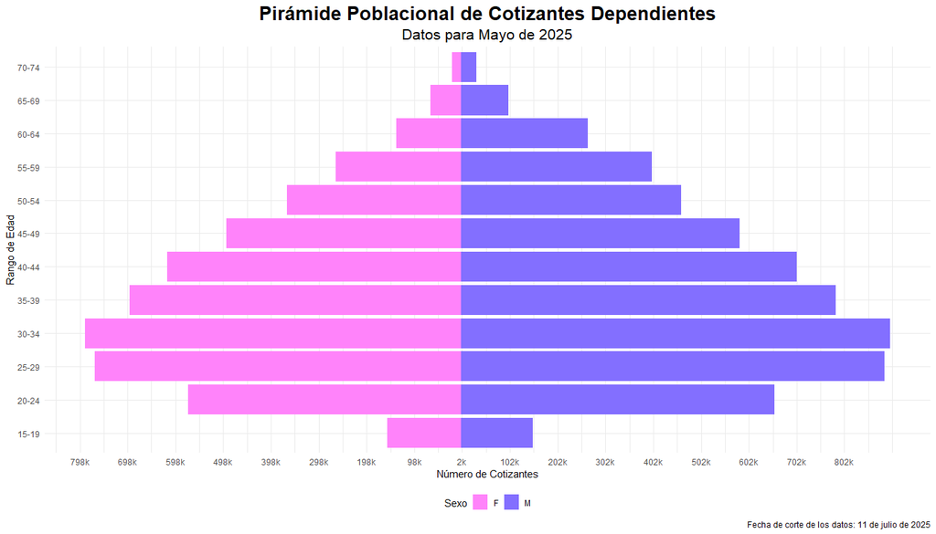

Resumen por sexo de los cotizantes independientes para Mayo de 2025 y meses anteriores

| Año | Mes | Total Hombres | Total Mujeres | Razón F/H | Hombres (%) | Mujeres (%) | Total Jóvenes | Jóvenes (%) |
| --- | --- | --- | --- | --- | --- | --- | --- | --- |
| 2025 | May | 1.095.482 | 1.127.712 | 102.9 | 49,3% | 50,7% | 240.051 | 10,8% |
| 2025 | Apr | 1.130.385 | 1.174.309 | 103.9 | 49,0% | 51,0% | 246.740 | 10,7% |
| 2025 | Mar | 1.180.038 | 1.211.977 | 102.7 | 49,3% | 50,7% | 249.787 | 10,4% |
| 2025 | Feb | 1.158.366 | 1.175.867 | 101.5 | 49,6% | 50,4% | 232.234 | 9,9% |

En contraste, los cotizantes independientes muestran una menor participación masculina (**49,3%**). La proporción de jóvenes en este grupo es del **10,8%**, mostrando una estructura etaria diferente a la de los dependientes.

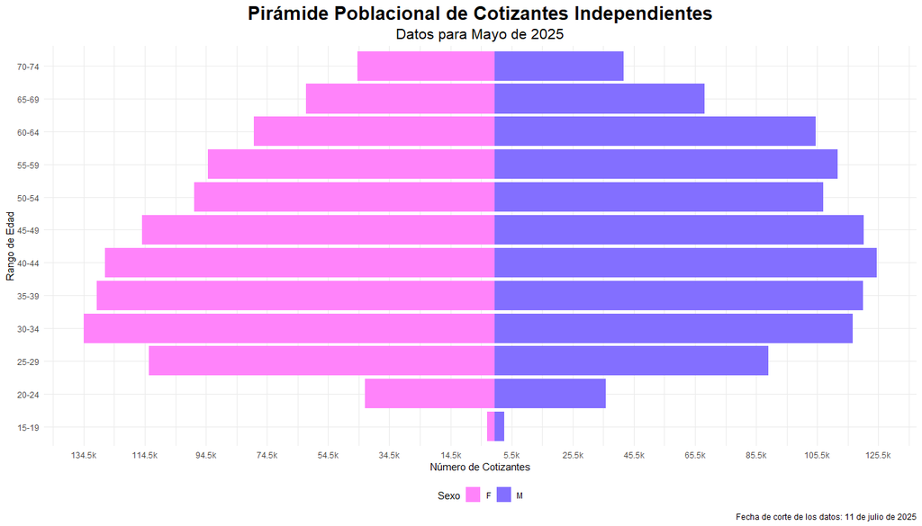

## 2.5 Dinámicas por departamento

La distribución geográfica de los cotizantes en Colombia permite identificar las regiones que concentran la mayor parte del empleo formal y analizar sus dinámicas de crecimiento. A continuación, se detalla el comportamiento para los cotizantes dependientes e independientes.

Resumen de cotizantes dependientes por Departamento

[output not shown]

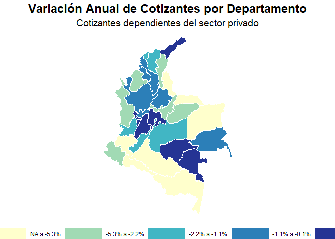

Para los cotizantes independientes, la dinámica regional muestra un comportamiento diferente. El mayor crecimiento anual se registró en **CAUCA** (**-0,6%**), mientras que la mayor caída se observó en **CAQUETÁ** (**-17,5%**).

Resumen de cotizantes independientes por Departamento

| Departamento | Total | % | Var. Anual |
| --- | --- | --- | --- |
| BOGOTÁ, D.C. | 665.222 | 29,9% | -7,8% |
| ANTIOQUIA | 347.669 | 15,6% | -2,1% |
| VALLE DEL CAUCA | 211.340 | 9,5% | -3,5% |
| CUNDINAMARCA | 123.804 | 5,6% | -1,6% |
| SANTANDER | 106.871 | 4,8% | -5,1% |
| ATLÁNTICO | 79.846 | 3,6% | -6,1% |
| RISARALDA | 54.753 | 2,5% | -3,2% |
| BOLÍVAR | 51.325 | 2,3% | -6,1% |
| BOYACÁ | 49.226 | 2,2% | -7,5% |
| TOLIMA | 48.950 | 2,2% | -7,2% |
| NORTE DE SANTANDER | 44.910 | 2,0% | -7,3% |
| CALDAS | 44.691 | 2,0% | -6,5% |
| NARIÑO | 43.613 | 2,0% | -8,9% |
| META | 43.276 | 1,9% | -6,2% |
| HUILA | 38.817 | 1,7% | -9,8% |
| CAUCA | 33.726 | 1,5% | -0,6% |
| QUINDIO | 30.860 | 1,4% | -3,1% |
| CÓRDOBA | 29.659 | 1,3% | -6,7% |
| MAGDALENA | 29.629 | 1,3% | -12,8% |
| CESAR | 29.306 | 1,3% | -10,4% |
| LA GUAJIRA | 22.008 | 1,0% | -12,5% |
| CASANARE | 19.969 | 0,9% | -7,5% |
| SUCRE | 14.505 | 0,7% | -11,4% |
| CAQUETÁ | 11.363 | 0,5% | -17,5% |
| PUTUMAYO | 10.876 | 0,5% | -15,8% |
| CHOCÓ | 10.708 | 0,5% | -13,4% |
| ARAUCA | 8.904 | 0,4% | -13,5% |
| ARCHIPIÉLAGO DE SAN ANDRÉS, PROVIDENCIA Y SANTA CATALINA | 6.323 | 0,3% | -11,3% |
| GUAVIARE | 3.951 | 0,2% | -11,0% |
| AMAZONAS | 3.802 | 0,2% | -7,7% |
| VICHADA | 2.614 | 0,1% | -4,1% |
| GUAINÍA | 1.935 | 0,1% | -10,8% |
| VAUPÉS | 1.496 | 0,1% | -16,9% |
| TOTAL | 2.225.947 | 100,0% | NA% |

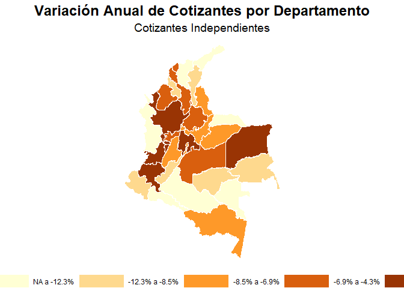

# 3 Aspectos metodológicos

## 3.1 Estimación interanual de las cotizaciones (Año tipo 2012 - 2019)

El **Índice Estacional Medio (IEM)** contrasta el número de relaciones laborales de un mes en particular sobre el total observado en enero de dicho año. La UGPP realiza una estimación del indicador con el fin de conocer el comportamiento típico de los cotizantes a lo largo del año y poder identificar cambios atipicos en los aportes.

## 3.2 Estimación de los cotizantes en cada enero.

El número esperado de cotizantes en enero 2023, sin la afectación económica, asciende a los 12,4 millones con un crecimiento del 2.2%. El crecimiento anual esperado en los dependientes es del 2.1% y en los independientes del 4.4%.

Total cotizantes estimados de enero en cada año despues de 2021

| Año | Total cotizantes | Var anual (%) | Cot. Dependientes | Var anual (%) | Cot. Dependientes | Var anual (%) |
| --- | --- | --- | --- | --- | --- | --- |
| 2023 | 12.458,6 | 2,2% | 10.219,0 | 2,1% | 2.341,2 | 4,4% |
| 2022 | 12.185,1 | 2,1% | 10.011,4 | 2,0% | 2.241,4 | 4,8% |
| 2021 | 11.930,2 | 2,1% | 9.819,0 | 1,9% | 2.138,6 | 4,3% |
| 2020 | 11.690,3 | 2,8% | 9.640,6 | 2,9% | 2.049,6 | 2,3% |
| 2019 | 11.369,7 | 1,4% | 9.366,2 | 2,1% | 2.003,6 | -1,8% |
| 2018 | 11.216,5 | 0,0% | 9.176,3 | 0,0% | 2.040,2 | 0,0% |